# Final Assignment

2024-01-10

The GitHub repository for this project can be found [here](https://github.com/methodology-asds/MY472-Final-Assignment).

### I. Introduction

Parliamentary questions ensure democratic accountability by allowing Member of Parliaments (MPs) to scrutinise governmental performance across a variety of issues. This study investigates the distinctions between MPs focusing on welfare and economic issues. After collecting data on a range of personal and constituency-level characteristics, a logistic regression model is computed to identify their impact on the likelihood of asking more welfare-focused questions in 2023.

### II. Data

**Outcome Variable**

Written and oral questions for the House of Commons were collected from the [Parliament API](https://developer.parliament.uk/) for 2023. As a proxy for issue type, answering departments were used to categorise questions into welfare and economic (Figure 1).

| Economic Issues | Welfare Issues |
| --- | --- |
| Treasury | Work & Pensions |
| Business and Trade | Health & Social Care |
| International Trade | Education |
| Business, Energy & Industrial Strategy | Levelling Up, Housing and Communities |

*Figure 1: Issue categorisation according to answering_department*

The resulting dataset contains 23,499 questions with the following issue distribution (Figure 2).

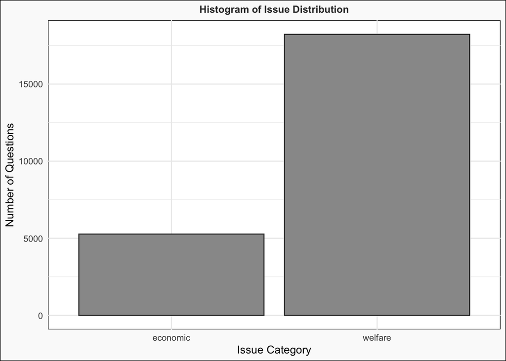

*Figure 2: Histogram of issue distribution*

Hence, MPs predominantly prioritise welfare issues. To address this emphasis, the outcome variable was determined by aggregating the number of welfare and economic questions asked by each MP and calculating the ratio between the two variables. MPs were classified as economic-focused (0) if the ratio exceeds the average ratio of economic to welfare questions (0.29), and welfare-focused otherwise. This process is outlined in the following equation:

$$\text{Welfare-Focused}_i =
\begin{cases} 1 & \text{if} \ \frac{\text{Number of Economic
Questions}_i}{\text{Number of Welfare Questions}_i} < 0.29 \\ 0 &
\text{otherwise} \end{cases}$$

**Personal Characteristics**

For MPs who asked questions in 2023, party and gender data were obtained from the Parliament API Members endpoint. Parties were categorized as left-, centre-, or right-leaning, while gender was turned into a binary variable.

Additionally, MPs’ age and education level were collected from their Wikipedia page. As some names coincided with several pages, RSelenium facilitated Google Searches with ‘wikipedia mp’ preceding each name to ensure the first result corresponded to the MP, and page URLs were collected. 3 exceptions were manually resolved. Wikipedia info-boxes were then scraped for relevant variables. Age was converted to numeric, and education was simplified categorically. Manual handling addressed 3 true missing age entries. Some errors in `education` may exist due to sporadic page format differences, but these are limited and should not significantly impact the analysis.

Finally, ethnicity data was gathered from the corresponding [Wikipedia table](https://en.wikipedia.org/wiki/List_of_ethnic_minority_politicians_in_the_United_Kingdom#List_of_ethnic_minority_Members_of_Parliament) and collapsed into a binary variable.

**Constituency-Level Data**

Electoral results, sourced from the [UK Parliament MPs page](https://members.parliament.uk), facilitated the calculation of the percentage difference between the winner and the runner-up. This aimed to explore if swing seats prompt a more balanced issue focus, given a potentially more politically diverse electorate.

Furthermore, census data on ethnic diversity, socio-economic classification, and education levels was collected. Ethnic diversity was summarised as a single variable representing the percentage of ethnic minorities per constituency. Socioeconomic and education indices were computed as such:

$$\text{Socioeconomic Index}_i =
\text{Unemployed}_i*1 + \text{Low Class}_i*2+\text{Intermediate
Class}_i*3+\text{High Class}_i*4$$
$$\text{Education Index}_i = \text{No Qualifications}_i*1 +
\text{GCSE}_i*2+\text{A-Levels}_i*3+\text{Other}_i*3.5+\text{Degree}_i*4$$

Note that the 3.5 weight associated with `education_other` illustrates its inclusion of post- A-levels and pre-university degrees. However, these weights were set arbitrarily, and a review of the extant literature would be useful for appropriate redefinition.

The final dataset takes the following form (Figure 3):

| Party | Gender | Age | Education | Ethnicity | Seat Safety (%) | Socioeconomic Index | Education Index | Ethnic Minorities (%) | Outcome: Welfare-focused |
| --- | --- | --- | --- | --- | --- | --- | --- | --- | --- |
| Categorical | Binary | Continous | Categorical | Binary | Continous | Continous | Continous | Continous | Binary |
| 238 (left) | Male (0) | 53.36 (mean) | A-Level (1) | Non-ethnic Minority (0) | 0.24 (mean) | 2.69 (mean) | 2.75 (mean) | 0.23 (mean) | Economic-Focused (0) |
| 37 (centre) | Female (1) | 11.27 (sd) | Undergraduate (2) | Ethnic Minority (1) | 0.16 (sd) | 0.20 (sd) | 0.21 (sd) | 0.21 (sd) | Welfare-Focused (1) |
| 247 (right) |  |  | Postgraduate (3) |  |  |  |  |  |  |
| 0 (NA) | 0 (NA) | 3 (NA) | 84 (NA) | 0 (NA) | 7 (NA) | 2 (NA) | 2 (NA) | 2 (NA) | 0 (NA) |

*Figure 3: Summary of variables used in the analysis*

### III. Analysis

To summarise each variable’s influence on whether an MP focuses on welfare issues, a logistic regression was computed. Due to the limited direct interpretability of such models, average marginal effects are presented (Figure 4).

| Variable | Marginal Effect | Standard Error |
| --- | --- | --- |
| Centre | 0.102 | 0.096 |
| Left | -0.096 | 0.059 |
| Gender | 0.103 | 0.052 |
| Age | -0.003 | 0.002 |
| Education | 0.052 | 0.049 |
| Ethnicity | 0.123 | 0.088 |
| Seat Safety | -0.029 | 0.153 |
| Socioeconomic Index | -0.079 | 0.196 |
| Education Index | 0.175 | 0.185 |
| Ethnic Minority | 0.095 | 0.151 |

*Figure 4: Average marginal effects on the probability of an MP focusing on welfare issues*

Additionally, Figure 5 illustrates the predicted probability change associated with a one-variable deviation from the average profile: a Conservative, male, white British MP aged 53 representing a constituency with a socio-economic index of 2.69, an education index of 2.75, and 23% ethnic minorities after winning with a 24% gap from the runner-up. These were derived from 1,000 model simulations to approximate true estimates.

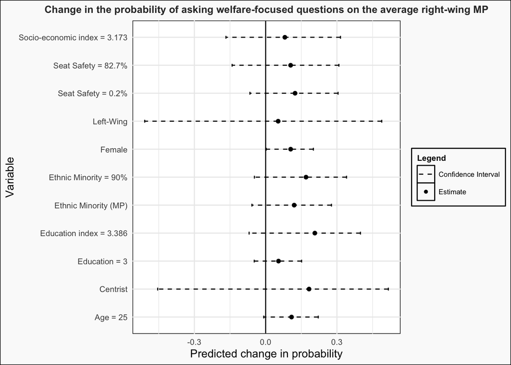

*Figure 5: Change in the probability of asking welfare-focused questions on the average right-wing MP*

### Data Sources

2021 Census Data for England and Wales:

- Education:https://commonslibrary.parliament.uk/constituency-data-educational-qualifications-2021-census/#explore_constituency
- Ethnicity: https://commonslibrary.parliament.uk/constituency-statistics-ethnicity/#single_constituency
- Socio-Economic Class: https://commonslibrary.parliament.uk/find-the-socio-economic-status-of-people-living-in-england-and-wales-by-constituency/

2021 Census Data for Northern Ireland:

- Education: https://build.nisra.gov.uk/en/custom/data?d=PEOPLE&v=PARLCON08&v=HIGHEST_QUALIFICATION_AGG7
- Ethnicity: https://build.nisra.gov.uk/en/custom/data?d=PEOPLE&v=PARLCON08&v=ETHNIC_GROUP_AGG5
- Socio-Economic Class: https://build.nisra.gov.uk/en/custom/data?d=PEOPLE&v=PARLCON08&v=NSSEC_FLAT_AGG10

2021 Census Data for Scotland (table builder): https://www.scotlandscensus.gov.uk/search-the-census#/topics

Parliament API: https://developer.parliament.uk/

Parliament Member page: https://members.parliament.uk

Wikipedia page on MPs belonging to an ethnic minority: https://en.wikipedia.org/wiki/List_of_ethnic_minority_politicians_in_the_United_Kingdom#List_of_ethnic_minority_Members_of_Parliament

### Appendix: R Code

```r
#Setting up the layout requirements
knitr::opts_chunk$set(echo = FALSE)
library(tidyverse)
library(httr)
library(rvest)
library(stringr)
library(RSelenium)
library(netstat)
library(mfx)
library(arm)
library(boot)
library(knitr)
clean_questions_data <- function(content, i) {
  name <- content$Response[[i]]$AskingMember$MnisId
  department <- content$Response[[i]]$AnsweringBody
  question <- content$Response[[i]]$QuestionText
  date <- content$Response[[i]]$TabledWhen
  issue_category <- ifelse(grepl('Education', department) | grepl('Work', department) | grepl('Health', department) | grepl('Housing', department), 'welfare', 'economic')
  data <- data.frame(department, question, name, date, issue_category)
  return(data)
}
#Initialise variables
answering_body_codes <- c(29, 17, 14, 214, 202, 201, 60, 7, 211)

entries <- 100

oral_questions <- data.frame(department = character(), question = character(), member = character(), date = Date(), issue_category = character(), stringsAsFactors = FALSE)

#Run first 100 entries as a standalone to get overall number of entries
initial_gathering <- GET('https://oralquestionsandmotions-api.parliament.uk/oralquestions/list?parameters.answeringDateStart=2023-01-01&parameters.answeringDateEnd=2023-12-31&parameters.answeringBodyIds=29&parameters.answeringBodyIds=17%20&parameters.answeringBodyIds=14&parameters.answeringBodyIds=214&parameters.answeringBodyIds=202%20&parameters.answeringBodyIds=201&parameters.answeringBodyIds=60&parameters.answeringBodyIds=7&parameters.answeringBodyIds=211&parameters.skip=0&parameters.take=100')

initial_gathering_content <- content(initial_gathering, 'parsed')

for (i in seq_along(initial_gathering_content$Response)) {
  data <- clean_questions_data(initial_gathering_content, i)
  oral_questions <- rbind(oral_questions, data)
}

#Get overall number of entries
overall_entries <- initial_gathering_content$PagingInfo$Total

#Get remaining entries
while(entries < overall_entries + 100) {
  message(entries)
  current_gathering <- GET(paste0('https://oralquestionsandmotions-api.parliament.uk/oralquestions/list?parameters.answeringDateStart=2023-01-01&parameters.answeringDateEnd=2023-12-31&parameters.answeringBodyIds=29&parameters.answeringBodyIds=17%20&parameters.answeringBodyIds=14&parameters.answeringBodyIds=214&parameters.answeringBodyIds=202%20&parameters.answeringBodyIds=201&parameters.answeringBodyIds=60&parameters.answeringBodyIds=7&parameters.answeringBodyIds=211&parameters.skip=', entries, '&parameters.take=100'))
  current_content <- content(current_gathering, 'parsed')

  for (i in seq_along(current_content$Response)) {
    data <- clean_questions_data(current_content, i)
    oral_questions <- rbind(oral_questions, data)
  }

  entries <- entries + 100
  Sys.sleep(1)
}
clean_written_questions_data <- function(content, i) {
  name <- content$results[[i]]$value$askingMemberId
  department <- content$results[[i]]$value$answeringBodyName
  question <- content$results[[i]]$value$questionText
  date <- content$results[[i]]$value$dateTabled
  issue_category <- ifelse(grepl('Education', department) | grepl('Work', department) | grepl('Health', department) | grepl('Housing', department), 'welfare', 'economic')
  data <- data.frame(department, question, name, date, issue_category)
  return(data)
}
#Initialise variables

entries_written <- 100

written_questions <- data.frame(department = character(), question = character(), member = numeric(), date = Date(), issue_category = character(), stringsAsFactors = FALSE)

#Run first 100 entries as a standalone to get overall number of entries
initial_gathering_written <- GET('https://questions-statements-api.parliament.uk/api/writtenquestions/questions?house=Commons&tabledWhenFrom=2023-01-01&tabledWhenTo=2023-12-31&answeringBodies=29&answeringBodies=17&answeringBodies=14&answeringBodies=214&answeringBodies=202&answeringBodies=201&answeringBodies=60&answeringBodies=7&answeringBodies=211&skip=0&take=100')

initial_gathering_content_written <- content(initial_gathering_written, 'parsed')

for (i in seq_along(initial_gathering_content_written$results)) {
  data <- clean_written_questions_data(initial_gathering_content_written, i)
  written_questions <- rbind(written_questions, data)
}

#Get overall number of entries
overall_entries_written <- initial_gathering_content_written$totalResults

#Get remaining entries
while(entries_written < overall_entries_written + 100) {
  message(entries_written)
  current_gathering <- GET(paste0('https://questions-statements-api.parliament.uk/api/writtenquestions/questions?house=Commons&tabledWhenFrom=2023-01-01&tabledWhenTo=2023-12-31&answeringBodies=29&answeringBodies=17&answeringBodies=14&answeringBodies=214&answeringBodies=202&answeringBodies=201&answeringBodies=60&answeringBodies=7&answeringBodies=211&skip=', entries_written, '&take=100'))
  current_content <- content(current_gathering, 'parsed')

  for (i in seq_along(current_content$results)) {
    data <- clean_written_questions_data(current_content, i)
    written_questions <- rbind(written_questions, data)
  }

  entries_written <- entries_written + 100
  Sys.sleep(1)
}
#Combine datasets
questions <- rbind(oral_questions, written_questions)

#Write csv (only run to add file to local drive)
#write.csv(questions, 'questions.csv', row.names = FALSE)
#Read csv file for questions
questions <- read.csv('data/questions.csv', stringsAsFactors = FALSE)
#Initialise dataframe
mps_data <- data.frame(id = numeric(), name = character(), party_id = numeric(), party_name = character(), gender = character(), membership_start_date = Date(), constituency = as.character(), stringsAsFactors = FALSE)

#Fetch data according to MP ID
for (i in unique(questions$name)) {
  message(i)
  url <- paste0('https://members-api.parliament.uk/api/Members/', i)
  data <- GET(url)
  content <- content(data, 'parsed')
  values <- content$value

  #Attach to dataframe
  mps_data <- rbind(mps_data, data.frame(id = i, name = values$nameDisplayAs, party_id = values$latestParty$id, party_name = values$latestParty$name, gender = values$gender, membership_start_date = values$latestHouseMembership$membershipStartDate, constituency = values$latestHouseMembership$membershipFrom, stringsAsFactors = FALSE))
```

```r
  Sys.sleep(1)
}
#Please note that this code worked at the time of data collection but has crashed occasionally since. This is being handled by printing an error message and continuing the search. Missing URLs can be imputed manually afterwards or this step can simply be replaced by merging the current variable to the one in the data folder (in mps_data.csv)

#Remove prefixes in MP's names
mps_data$name <- gsub('(?:Mr |Mrs |Dr |Sir |Dame |Ms |Miss )', '', mps_data$name)

#Initialise URL variable to NAs
mps_data$url <- NA

rD <- rsDriver(browser=c("firefox"), port = free_port(random = TRUE), chromever = NULL,  verbose = FALSE)
driver <- rD$client

#Initialise iteration
iteration <- 1

#Navigate to google and search for MP's wikipedia page
for (i in seq_along(mps_data$name)) {
  #Print MP's name
  message(mps_data$name[i])
  driver$navigate("https://www.google.com/")

  #For first iteration, accept Google's terms and conditions
  if (iteration == 1) {
    Sys.sleep(1)
    agree_button <- driver$findElement(using = "xpath", value = '/html/body/div[2]/div[3]/div[3]/span/div/div/div/div[3]/div[1]/button[2]/div')
    agree_button$clickElement()
    iteration <- iteration + 1
  }

  search_field <- driver$findElement(using = "xpath", value = '//*[@id="APjFqb"]')
  search_field$sendKeysToElement(list(paste0('wikipedia mp '), mps_data$name[i]))
  search_field$sendKeysToElement(list(key = "enter"))
  Sys.sleep(1.5)

  #Get first element
  tryCatch({
    first_element <- driver$findElement(using = 'css selector', value = 'div.g a')
    first_element$clickElement()

    #Get URL
    get_url <- driver$getCurrentUrl()
    mps_data$url[i] <- get_url[[1]]
  }, error = function(e) {
    print('URL not found')
  })
  Sys.sleep(1.5)
}

#Close driver
driver$close()
rD$server$stop()
#Account for exceptions
mps_data$url[which(mps_data$name == 'Stella Creasy')] <- 'https://en.wikipedia.org/wiki/Stella_Creasy'
mps_data$url[which(mps_data$name == 'Alex Norris')] <- 'https://en.wikipedia.org/wiki/Alex_Norris_(British_politician)'
mps_data$url[which(mps_data$name == 'Ian Paisley')] <- 'https://en.wikipedia.org/wiki/Ian_Paisley_Jr'

#Get MP's age and education from Wikipedia
for (i in mps_data$url) {
  message(mps_data$name[which(i == mps_data$url)])
  data <- read_html(i)
  infolabel <- data %>% html_elements(css = ".infobox-label") %>% html_text()
  infodata <- data %>% html_elements(css = ".infobox-data") %>% html_text()
  age <- infodata[infolabel == 'Born']
  age <- str_match(age, 'age\\s*(.+)$')[2]
  age <- sub("\\).*", "", age)
  age <- strsplit(age, '–')
  age <- as.numeric(unlist(age))
  mps_data$age[which(mps_data$url == i)] <- mean(age)

  if ('Alma mater' %in% infolabel) {
    education <- infodata[infolabel == 'Alma mater']
    education <- strsplit(education, "(?<=[a-z])(?=[A-Z])", perl = TRUE)
    education <- unlist(education)
    #If Alma mater has more than one entry, code 3 (high education level), else code 2
    if (length(education) > 1) {
      mps_data$education[which(mps_data$url == i)] <- 3
    } else {
      mps_data$education[which(mps_data$url == i)] <- 2
    }
    #If Alma mater has no entry, code 1 (low education level)
  } else if (('Education' %in% infolabel) & !('Alma mater' %in% infolabel)) {
      mps_data$education[which(mps_data$url == i)] <- 1

  } else {
      mps_data$education[which(mps_data$url == i)] <- NA
  }
  Sys.sleep(0.5)
}

#Handcode a few missing values which did not fit the pattern for age
mps_data$age[which(mps_data$name == 'Neil Hudson')] <- 54
mps_data$age[which(mps_data$name == 'Caroline Dinenage')] <- 52
mps_data$age[which(mps_data$name == 'Kate Kniveton')] <- 52
#Read html for ethnic minority politicians
url <- 'https://en.wikipedia.org/wiki/List_of_ethnic_minority_politicians_in_the_United_Kingdom'
wikipedia_data <- read_html(url)
wikipedia_tables <- html_table(wikipedia_data)

#Get table for Parliament members
ethnicity_mp <- wikipedia_tables[[6]]

#Fill in variable
for (i in seq_along(mps_data$name)) {
  mps_data$ethnicity[i] <- ifelse(any(grepl(mps_data$name[i], ethnicity_mp$Name)),
                                   ethnicity_mp$Ethnicity[which(grepl(mps_data$name[i], ethnicity_mp$Name))[1]], 'White British')
}
#Get last electoral results
#Initialise variable
mps_data$vote_difference <- NA

#For each MP's id, navigate to election result page
for (i in seq_along(mps_data$id)) {
  message(mps_data$name[i])
  current_url <- paste0('https://members.parliament.uk/member/', mps_data$id[i], '/electionresult')
  tryCatch({
    data <- read_html(current_url)
    table <- html_table(data)

    # Extracting vote information and converting to numeric
    vote_first <- as.numeric(sub('%', '', table[[1]][1, 4]))
    vote_second <- as.numeric(sub('%', '', table[[1]][2, 4]))

    # Calculating the vote difference
    mps_data$vote_difference[i] <- vote_first - vote_second
  }, error = function(e) {
    # If an error occurs, handle it by printing error
    print('no value available for this MP')
  })
  Sys.sleep(0.5)
}
#Write csv file (run to add to local drive)
#write_csv(mps_data, 'mps_data.csv')
#Read csv file
mps_data <- read.csv('data/mps_data.csv', stringsAsFactors = FALSE)
### For England and Wales ###
census_ethnicity <- read.csv('data/ethnicity_2021.csv', stringsAsFactors = FALSE)

constituency_ethnicity <- census_ethnicity %>%
  group_by(ConstituencyName) %>%
  summarise(
    perc_whitebritish = Con_pc[ethnic_groups == 'English, Welsh, Scottish, Northern Irish or British'],
    perc_asian = sum(Con_pc[broad_ethnic_groups == 'Asian'], na.rm = TRUE),
    perc_black = sum(Con_pc[broad_ethnic_groups == 'Black'], na.rm = TRUE),
    perc_mixed = sum(Con_pc[broad_ethnic_groups == 'Mixed or Multiple ethnic groups'], na.rm = TRUE),
    perc_other = sum(Con_pc[broad_ethnic_groups == 'Other'], na.rm = TRUE) + Con_pc[ethnic_groups == 'Irish'] + Con_pc[ethnic_groups == 'Gypsy or Irish Traveller'] +  Con_pc[ethnic_groups == 'Roma'] + Con_pc[ethnic_groups == 'Other White'])

### For Scotland ###
scotland_ethnicity <- read.csv('data/scottish_ethnicity_data.csv', stringsAsFactors = FALSE)
```

```r
#Calculate percentages
scotland_ethnicity$perc_whitebritish <- (scotland_ethnicity$White..Scottish + scotland_ethnicity$White..Other.British)/scotland_ethnicity$All.people

scotland_ethnicity$perc_asian <- scotland_ethnicity$Asian..Asian.Scottish.or.Asian.British/scotland_ethnicity$All.people

scotland_ethnicity$perc_black <- (scotland_ethnicity$African + scotland_ethnicity$Caribbean.or.Black)/scotland_ethnicity$All.people

scotland_ethnicity$perc_mixed <- scotland_ethnicity$Mixed.or.multiple.ethnic.groups/scotland_ethnicity$All.people

scotland_ethnicity$perc_other <- (scotland_ethnicity$Other.ethnic.groups + scotland_ethnicity$White..Irish + scotland_ethnicity$White..Gypsy.Traveller + scotland_ethnicity$White..Polish + scotland_ethnicity$White..Other.White)/scotland_ethnicity$All.people

#Remove other columns
scotland_ethnicity <- scotland_ethnicity[, c(1, 28:32)]

#Rename columns
names(scotland_ethnicity) <- c('ConstituencyName', 'perc_whitebritish', 'perc_asian', 'perc_black', 'perc_mixed', 'perc_other')

#Concatenate datasets
ethnicity <- rbind(constituency_ethnicity, scotland_ethnicity)

### For Northern Ireland (note that Northern Ireland does not distinguish between White British and Other White, they will be classify as White British) ###

nireland_ethnicity <- read.csv('data/northern_ireland_ethnicity.csv')

#Calculate percentages
nireland_ethnicity_perc <- nireland_ethnicity %>%
  group_by(Parliamentary.Constituency.2008.Label) %>%
  summarise(
    perc_whitebritish = Count[Ethnic.Group...5.Categories.Label == 'White']/sum(Count),
    perc_asian = Count[Ethnic.Group...5.Categories.Label == 'Asian']/sum(Count),
    perc_black = Count[Ethnic.Group...5.Categories.Label == 'Black']/sum(Count),
    perc_mixed = Count[Ethnic.Group...5.Categories.Label == 'Mixed']/sum(Count),
    perc_other = Count[Ethnic.Group...5.Categories.Label == 'Other']/sum(Count)
  )

names(nireland_ethnicity_perc) <- c('ConstituencyName', 'perc_whitebritish', 'perc_asian', 'perc_black', 'perc_mixed', 'perc_other')
ethnicity <- rbind(ethnicity, nireland_ethnicity_perc)

#Merge with main dataset
mps_data_new <- merge(mps_data, ethnicity, by.x = 'constituency', by.y = 'ConstituencyName', all.x = TRUE)
### For England and Wales ###
ew_socioeconomic <- read.csv('data/ew_census_socioeconomic.csv', stringsAsFactors = FALSE)

ew_socioeconomic_cleaned <- ew_socioeconomic %>%
  group_by(ConstituencyName) %>%
  summarise(
    perc_unemployed = Con_pc[groups == 'Never worked / long-term unemployed'] + Con_pc[groups == 'Full-time students'],
    perc_low = sum(Con_pc[groups == 'Routine and manual occupations']),
    perc_med = sum(Con_pc[groups == 'Intermediate occupations']),
    perc_high = sum(Con_pc[groups == 'Managerial, administrative and professional occupations'])
  )

#### For Scotland ###
scotland_socioeconomic <- read.csv('data/scotland_socioeconomic_data.csv', stringsAsFactors = FALSE)

scotland_socioeconomic$perc_unemployed <- (scotland_socioeconomic$L15.Full.time.students + scotland_socioeconomic$X8..Never.worked.and.long.term.unemployed..L14.2.Long.term.unemployed + scotland_socioeconomic$X8..Never.worked.and.long.term.unemployed..L14.1.Never.worked)/scotland_socioeconomic$All.people.aged.16.to.74

scotland_socioeconomic$perc_low <- (scotland_socioeconomic$X7..Routine.occupations + scotland_socioeconomic$X6..Semi.routine.occupations + scotland_socioeconomic$X5...Lower.supervisory.and.technical.occupations)/scotland_socioeconomic$All.people.aged.16.to.74

scotland_socioeconomic$perc_med <- (scotland_socioeconomic$X4..Small.employers.and.own.account.workers + scotland_socioeconomic$X3..Intermediate.occupations)/scotland_socioeconomic$All.people.aged.16.to.74

scotland_socioeconomic$perc_high <- (scotland_socioeconomic$X2..Lower.managerial.and.professional.occupations + scotland_socioeconomic$X1..Higher.managerial..administrative.and.professional.occupations..1.2.Higher.professional.occupations + scotland_socioeconomic$X1..Higher.managerial..administrative.and.professional.occupations..1.1.Large.employers.and.higher.managerial.occupations)/scotland_socioeconomic$All.people.aged.16.to.74

scotland_socioeconomic_cleaned <- scotland_socioeconomic[, c(1, 14:17)]
names(scotland_socioeconomic_cleaned) <- c('ConstituencyName', 'perc_unemployed', 'perc_low', 'perc_med', 'perc_high')

socioeconomic <- rbind(ew_socioeconomic_cleaned, scotland_socioeconomic_cleaned)

### For Northern Ireland ###
ni_socioeconomic <- read.csv('data/ni_socioeconomic_data.csv', stringsAsFactors = FALSE)

ni_socioeconomic_cleaned <- ni_socioeconomic %>%
  group_by(Parliamentary.Constituency.2008.Label) %>%
  summarise(
    perc_unemployed = (Count[National.Statistics.Socio.economic.Classification...10.Categories.Label == 'L15: Full-time students'] +
      Count[National.Statistics.Socio.economic.Classification...10.Categories.Label == 'L14.1, L14.2: Never worked and long-term unemployed'])/(sum(Count) - Count[National.Statistics.Socio.economic.Classification...10.Categories.Label == 'No code required']),
    perc_low = (Count[National.Statistics.Socio.economic.Classification...10.Categories.Label == 'L13: Routine occupations'] + Count[National.Statistics.Socio.economic.Classification...10.Categories.Label == 'L12: Semi-routine occupations'] + Count[National.Statistics.Socio.economic.Classification...10.Categories.Label == 'L10, L11: Lower supervisory and technical occupations'])/ (sum(Count) - Count[National.Statistics.Socio.economic.Classification...10.Categories.Label == 'No code required']),
    perc_med = (Count[National.Statistics.Socio.economic.Classification...10.Categories.Label == 'L8, L9: Small employers and own account workers'] + Count[National.Statistics.Socio.economic.Classification...10.Categories.Label == 'L7: Intermediate occupations'])/(sum(Count) - Count[National.Statistics.Socio.economic.Classification...10.Categories.Label == 'No code required']),
    perc_high = (Count[National.Statistics.Socio.economic.Classification...10.Categories.Label == 'L4, L5, L6: Lower managerial, administrative and professional occupations'] + Count[National.Statistics.Socio.economic.Classification...10.Categories.Label == 'L1, L2, L3: Higher managerial, administrative and professional occupations'])/(sum(Count) - Count[National.Statistics.Socio.economic.Classification...10.Categories.Label == 'No code required'])
  )
```

```r
names(ni_socioeconomic_cleaned) <- c('ConstituencyName', 'perc_unemployed', 'perc_low', 'perc_med', 'perc_high')

socioeconomic <- rbind(socioeconomic, ni_socioeconomic_cleaned)
### For England and Wales ###
ew_education <- read.csv('data/ew_education_data.csv', stringsAsFactors = FALSE)

ew_education_cleaned <- ew_education %>%
  group_by(ConstituencyName) %>%
  summarise(
    perc_no_qualification = sum(Con_pc[groups == 'No qualifications']),
    perc_GCSEs = sum(Con_pc[groups == '1 or more GCSEs']),
    perc_Alevels = sum(Con_pc[groups == '2 or more A levels']),
    perc_higher = sum(Con_pc[groups == 'Higher education qualifications']),
    perc_other = Con_pc[groups == 'Apprenticeship'] + Con_pc[groups == 'Other qualifications']
  )

### For Scotland ###
scotland_education <- read.csv('data/scotland_education_data.csv', stringsAsFactors = FALSE)
scotland_education$perc_no_qualification <- scotland_education$No.qualifications/scotland_education$Total
scotland_education$perc_GCSEs <- scotland_education$Level.1/ scotland_education$Total
scotland_education$perc_Alevels <- scotland_education$Level.2/scotland_education$Total
scotland_education$perc_higher <- scotland_education$Level.4.and.above/scotland_education$Total
scotland_education$perc_other <- scotland_education$Level.3/scotland_education$Total

scotland_education <- scotland_education[, c(1, 8:12)]
names(scotland_education) <- c('ConstituencyName', 'perc_no_qualification', 'perc_GCSEs', 'perc_Alevels', 'perc_higher', 'perc_other')
education <- rbind(ew_education_cleaned, scotland_education)

### For Northern Ireland ###
ni_education <- read.csv('data/ni_education_data.csv', stringsAsFactors = FALSE)
ni_education_cleaned <- ni_education %>%
  group_by(Parliamentary.Constituency.2008.Label) %>%
  summarise(
    perc_no_qualification = (Count[Qualifications..Highest.Level....7.Categories.Label == 'No qualifications'])/(sum(Count) - Count[Qualifications..Highest.Level....7.Categories.Label == 'No code required']),
    perc_GCSEs = (Count[Qualifications..Highest.Level....7.Categories.Label == 'Level 1: 1 to 4 GCSEs, O levels, CSEs (any grades); 1 AS Level; NVQ level 1; or equivalent'] + Count[Qualifications..Highest.Level....7.Categories.Label == 'Level 2: 5 or more GCSEs (A*-C or 9-4), O levels (passes) CSEs (grade 1); 1 A level, 2-3 AS Levels; NVQ level 2, BTEC General, City and Guilds Craft; or equivalent'])/(sum(Count) - Count[Qualifications..Highest.Level....7.Categories.Label == 'No code required']),
    perc_Alevels = (Count[Qualifications..Highest.Level....7.Categories.Label == 'Level 3: 2 or more A Levels, 4 or more AS Levels; NVQ Level 3, BTEC National, OND, ONC, City and Guilds Advanced Craft; or equivalent'])/(sum(Count) - Count[Qualifications..Highest.Level....7.Categories.Label == 'No code required']),
    perc_higher = (Count[Qualifications..Highest.Level....7.Categories.Label == 'Level 4 and above: Degree (BA, BSc), foundation degree, NVQ Level 4 and above, HND, HNC, professional qualifications (teaching or nursing, for example), or equivalent'])/(sum(Count) - Count[Qualifications..Highest.Level....7.Categories.Label == 'No code required']),
    perc_other = (Count[Qualifications..Highest.Level....7.Categories.Label == 'Other: Apprenticeships; other qualifications, equivalent unknown'])/(sum(Count) - Count[Qualifications..Highest.Level....7.Categories.Label == 'No code required'])
  )

names(ni_education_cleaned) <- c('ConstituencyName', 'perc_no_qualification', 'perc_GCSEs', 'perc_Alevels', 'perc_higher', 'perc_other')
education <- rbind(education, ni_education_cleaned)
#Condense socio-economic and education in one variable
socioeconomic <- socioeconomic %>%
  mutate(socioeconomic_index = perc_unemployed*1 + perc_low*2 + perc_med*3 + perc_high*4)

education <- education %>%
  mutate(education_index = perc_no_qualification*1 + perc_GCSEs*2 + perc_Alevels*3 + perc_other*3.5 + perc_higher*4)

#Merge with mps data
mps_data_new <- left_join(mps_data_new, socioeconomic %>% dplyr::select(ConstituencyName, socioeconomic_index), by = c("constituency" = "ConstituencyName"))

mps_data_new <- left_join(mps_data_new, education %>% dplyr::select(ConstituencyName, education_index), by = c("constituency" = "ConstituencyName"))

#Combine ethnic minorities into one variable
mps_data_new$perc_ethnic_minority <- mps_data_new$perc_asian + mps_data_new$perc_black + mps_data_new$perc_mixed + mps_data_new$perc_other

#Drop unnecessary variables
mps_data_new <- mps_data_new[, -c(13:17)]

#Make gender binary where 0 = Male
mps_data_new$gender <- ifelse(mps_data_new$gender == 'M', 0, 1)

#Combine some parties
mps_data_new$party_name <- ifelse(mps_data_new$party_name %in% c('Conservative', 'Democratic Unionist Party'), 'Right', mps_data_new$party_name)

mps_data_new$party_name <- ifelse(mps_data_new$party_name %in% c('Labour', 'Labour (Co-op)', 'Scottish National Party', 'Social Democratic & Labour Party', 'Green Party', 'Alba Party', 'Plaid Cymru'), 'Left', mps_data_new$party_name)

mps_data_new$party_name <- ifelse(mps_data_new$party_name %in% c('Independent', 'Liberal Democrat', 'Alliance'), 'Centre', mps_data_new$party_name)

#Make ethnicity binary
mps_data_new$ethnicity <- ifelse(mps_data_new$ethnicity == 'White British', 0, 1)

#Divide vote_difference by 100 to match other percentages
mps_data_new$vote_difference <- mps_data_new$vote_difference/100
#Write summary table
department_table <- tibble(
  Economic_Issue = c('Treasury', 'Business and Trade', 'International Trade', 'Business, Energy & Industrial Strategy'),
  Welfare_Issue = c( 'Work & Pensions', 'Health & Social Care', 'Education', 'Levelling Up, Housing and Communities')
)

kable(department_table, col.names = c('Economic Issues', 'Welfare Issues'))

#Call print to see within R Markdown
#print(department_table)
#Plot histogram of issue distribution
ggplot(questions, aes(x = issue_category)) +
  geom_bar(fill = 'gray60', color = 'gray20') +
  labs(x = 'Issue Category', y = 'Number of Questions', title = 'Histogram of Issue Distribution') +
  theme_minimal() +
  theme(panel.background = element_rect(fill = 'white'), plot.background = element_rect(fill = 'grey98'),
        plot.title = element_text(size = 10, colour = 'gray20', face = 'bold', hjust = 0.5))
```

```r
#Count number of questions on economic and welfare topics asked by each MP
for (i in 1:nrow(mps_data_new)) {
  mps_data_new$econ_questions[i] <- nrow(filter(questions, name == mps_data_new$id[i] & issue_category == 'economic'))
  mps_data_new$welfare_questions[i] <- nrow(filter(questions, name == mps_data_new$id[i] & issue_category == 'welfare'))
}

#Create outcome variable

#Calculate mean ratio
issue_counts <- table(questions$issue_category)
average_ratio <- mean(issue_counts['economic']/issue_counts['welfare'])

for (i in 1:nrow(mps_data_new)) {
  if (mps_data_new$econ_questions[i] == 0) {
    mps_data_new$welfare_focused[i] <- 1
  } else if (mps_data_new$welfare_questions[i] == 0) {
    mps_data_new$welfare_focused[i] <- 0
  } else if (mps_data_new$econ_questions[i]/mps_data_new$welfare_questions[i] > average_ratio) {
    mps_data_new$welfare_focused[i] <- 0
  } else if (mps_data_new$econ_questions[i]/mps_data_new$welfare_questions[i] < average_ratio) {
    mps_data_new$welfare_focused[i] <- 1
  } else {
    mps_data_new$welfare_focused[i] <- NA
  }
}

#Drop additional columns
mps_data_analysis <- mps_data_new[, -c(1:4, 8, 16, 17)]

#Relevel party_name
mps_data_analysis$party_name <- relevel(factor(mps_data_analysis$party_name), ref = "Right")
summary_table <- tibble(
  Party = c('Categorical', '238 (left)', '37 (centre)', '247 (right)', '0 (NA)'),
  Gender = c('Binary', 'Male (0)', 'Female (1)', '', '0 (NA)'),
  Age = c('Continous', '53.36 (mean)', '11.27 (sd)', '', '3 (NA)'),
  Education = c('Categorical', 'A-Level (1)', 'Undergraduate (2)', 'Postgraduate (3)', '84 (NA)'),
  Ethnicity = c('Binary', 'Non-ethnic Minority (0)', 'Ethnic Minority (1)','', '0 (NA)'),
  Vote_Difference = c('Continous', '0.24 (mean)', '0.16 (sd)', '', '7 (NA)'),
  Socioeconomic_Index = c('Continous', '2.69 (mean)', '0.20 (sd)', '', '2 (NA)'),
  Education_Index = c('Continous', '2.75 (mean)', '0.21 (sd)', '', '2 (NA)'),
  Perc_Ethnic_Minority = c('Continous', '0.23 (mean)', '0.21 (sd)', '',  '2 (NA)'),
  Welfare_Focused = c('Binary', 'Economic-Focused (0)', 'Welfare-Focused (1)', '', '0 (NA)')
)

kable(summary_table, col.names = c('Party', 'Gender', 'Age', 'Education', 'Ethnicity', 'Seat Safety (%)', 'Socioeconomic Index', 'Education Index', 'Ethnic Minorities (%)', 'Outcome: Welfare-focused'), align = 'l')

#Run to show results in Markdown
#summary(mps_data_analysis)
#sd(mps_data_analysis$age, na.rm = TRUE)
#sd(mps_data_analysis$vote_difference, na.rm = TRUE)
#sd(mps_data_analysis$socioeconomic_index, na.rm = TRUE)
#sd(mps_data_analysis$education_index, na.rm = TRUE)
#sd(mps_data_analysis$perc_ethnic_minority, na.rm = TRUE)
model <- glm(formula = welfare_focused ~ party_name + gender + age + education + ethnicity + vote_difference + socioeconomic_index + education_index + perc_ethnic_minority, data = mps_data_analysis, family = binomial(link = 'logit'))
#Calculate average marginal effects (to run for results in R Markdown)
logitmfx(model, data = mps_data_analysis, atmean = FALSE)
#Create table
marginal_effects <- tibble(
  Variable = c('Centre', 'Left', 'Gender', 'Age', 'Education', 'Ethnicity', 'Seat Safety', 'Socioeconomic Index', 'Education Index', 'Ethnic Minority'),
  Marginal_Effect = c(0.102, -0.096, 0.103, -0.003, 0.052, 0.123, -0.029, -0.079, 0.175, 0.095),
  Standard_Error = c(0.096, 0.059, 0.052, 0.002, 0.049, 0.088, 0.153, 0.196, 0.185, 0.151)
)

kable(marginal_effects, col.names = c('Variable', 'Marginal Effect', 'Standard Error'), align = 'l')
#Run a simulation of the model 1000 times to approximate true coefficients and standard errors
simulation <- sim(model, n.sims = 1000)

#Extract coefficients
coefficients_sim <- coef(simulation)

#Calculate predicted probabilities for the average right-wing MP
reference_profile <- c(1, 0, 0, 0, 53, 2, 0, 0.24, 2.69, 2.75, 0.23)
reference_predicted <- inv.logit(reference_profile %*% t(coefficients_sim))

#Calculate predicted probabilities for the average centrist MP
centrist_profile <- c(0, 1, 0, 0, 53, 2, 0, 0.24, 2.69, 2.75, 0.23)
centrist_predicted <- inv.logit(centrist_profile %*% t(coefficients_sim))

#Calculate predicted probabilities for the average left-wing MP
left_profile <- c(0, 0, 1, 0, 53, 2, 0, 0.24, 2.69, 2.75, 0.23)
left_predicted <- inv.logit(left_profile %*% t(coefficients_sim))

#Calculate predicted probabilities for the average female right-wing MP
female_profile <- c(1, 0, 0, 1, 53, 2, 0, 0.24, 2.69, 2.75, 0.23)
female_predicted <- inv.logit(female_profile %*% t(coefficients_sim))

#Calculate predicted probabilities for a young (25) right-wing MP
young_profile <- c(1, 0, 0, 0, 25, 2, 0, 0.24, 2.69, 2.75, 0.23)
young_predicted <- inv.logit(young_profile %*% t(coefficients_sim))

#Calculate predicted probabilities for a well-educated (3) right-wing MP
educated_profile <- c(1, 0, 0, 0, 53, 3, 0, 0.24, 2.69, 2.75, 0.23)
educated_predicted <- inv.logit(educated_profile %*% t(coefficients_sim))

#Calculate predicted probabilities for a right-wing MP from an ethnic minority
minority_profile <- c(1, 0, 0, 0, 53, 2, 1, 0.24, 2.69, 2.75, 0.23)
minority_predicted <- inv.logit(minority_profile %*% t(coefficients_sim))

#Calculate predicted probabilities for a right-wing MP with a swing seat
swing_profile <- c(1, 0, 0, 0, 53, 2, 1, 0.002, 2.69, 2.75, 0.23)
swing_predicted <- inv.logit(swing_profile %*% t(coefficients_sim))

#Calculate predicted probabilities for a right-wing MP with a safe seat
safe_profile <- c(1, 0, 0, 0, 53, 2, 1, 0.827, 2.69, 2.75, 0.23)
safe_predicted <- inv.logit(safe_profile %*% t(coefficients_sim))

#Calculate predicted probabilities for a right-wing MP from a constituency with a high socioeconomic index
highsocio_profile <- c(1, 0, 0, 0, 53, 2, 1, 0.24, 3.173, 2.75, 0.23)
highsocio_predicted <- inv.logit(highsocio_profile %*% t(coefficients_sim))

#Calculate predicted probabilities for a right-wing MP from a constituency with a high education index
highedu_profile <- c(1, 0, 0, 0, 53, 2, 1, 0.24, 2.69, 3.386, 0.23)
highedu_predicted <- inv.logit(highedu_profile %*% t(coefficients_sim))
```

```r
#Calculate predicted probabilities for a right-wing MP from a constituency with a high percentage of ethnic minorities
highminority_profile <- c(1, 0, 0, 0, 53, 2, 1, 0.24, 2.69, 2.75, 0.90)
highminority_predicted <- inv.logit(highminority_profile %*% t(coefficients_sim))

#Compute changes in predicted probabilities
centrist_change <- centrist_predicted - reference_predicted
centrist_mean <- mean(centrist_change)
centrist_ub <- quantile(centrist_change, 0.975)
centrist_lb <- quantile(centrist_change, 0.025)

left_change <- left_predicted - reference_predicted
left_mean <- mean(left_change)
left_ub <- quantile(left_change, 0.975)
left_lb <- quantile(left_change, 0.025)

female_change <- female_predicted - reference_predicted
female_mean <- mean(female_change)
female_ub <- quantile(female_change, 0.975)
female_lb <- quantile(female_change, 0.025)

young_change <- young_predicted - reference_predicted
young_mean <- mean(young_change)
young_ub <- quantile(young_change, 0.975)
young_lb <- quantile(young_change, 0.025)

educated_change <- educated_predicted - reference_predicted
educated_mean <- mean(educated_change)
educated_ub <- quantile(educated_change, 0.975)
educated_lb <- quantile(educated_change, 0.025)

minority_change <- minority_predicted - reference_predicted
minority_mean <- mean(minority_change)
minority_ub <- quantile(minority_change, 0.975)
minority_lb <- quantile(minority_change, 0.025)

swing_change <- swing_predicted - reference_predicted
swing_mean <- mean(swing_change)
swing_ub <- quantile(swing_change, 0.975)
swing_lb <- quantile(swing_change, 0.025)

safe_change <- safe_predicted - reference_predicted
safe_mean <- mean(safe_change)
safe_ub <- quantile(safe_change, 0.975)
safe_lb <- quantile(safe_change, 0.025)

highsocio_change <- highsocio_predicted - reference_predicted
highsocio_mean <- mean(highsocio_change)
highsocio_ub <- quantile(highsocio_change, 0.975)
highsocio_lb <- quantile(highsocio_change, 0.025)

highedu_change <- highedu_predicted - reference_predicted
highedu_mean <- mean(highedu_change)
highedu_ub <- quantile(highedu_change, 0.975)
highedu_lb <- quantile(highedu_change, 0.025)

highminority_change <- highminority_predicted - reference_predicted
highminority_mean <- mean(highminority_change)
highminority_ub <- quantile(highminority_change, 0.975)
highminority_lb <- quantile(highminority_change, 0.025)

#Create table
results <- data.frame(
  'Variable' = as.factor(c('Centrist', 'Left-Wing', 'Female', 'Age = 25', 'Education = 3', 'Ethnic Minority (MP)', 'Seat Safety = 0.2%', 'Seat Safety = 82.7%', 'Socio-economic index = 3.173', 'Education index = 3.386', 'Ethnic Minority = 90%')),
  'CIPP' = c(centrist_mean, left_mean, female_mean, young_mean, educated_mean, minority_mean, swing_mean, safe_mean, highsocio_mean, highedu_mean, highminority_mean),
  'ciLB' = c(centrist_lb, left_lb, female_lb, young_lb, educated_lb, minority_lb, swing_lb, safe_lb, highsocio_lb, highedu_lb, highminority_lb),
  'ciUB' = c(centrist_ub, left_ub, female_ub, young_ub, educated_ub, minority_ub, swing_ub, safe_ub, highsocio_ub, highedu_ub, highminority_ub))

#Plot change in predicted probabilities
ggplot(results, aes(CIPP, Variable)) +
  geom_point(aes(colour = 'Estimate'), size = 1.5) + #Plot mean change
  geom_errorbarh(aes(xmin = ciLB, xmax = ciUB, colour = 'Confidence Interval'), size = 0.5, linetype = 2, height = 0.1) + #Plot confidence interval
  geom_vline(aes(xintercept = 0)) + #Add a vertical line at 0
  scale_color_manual( name = 'Legend', values = c('black', 'black'), ) + #Add a legend
  xlab('Predicted change in probability') + #Add a title for the x-axis
  ylab('Variable') + #Add a title for the y-axis
  guides(color = guide_legend(override.aes = list(linetype = c(2, 0), shape = c(NA,16)) ) ) + #Change legend symbols
  ggtitle('Change in the probability of asking welfare-focused questions on the average right-wing MP') + #Add a title
  theme_minimal() +
  theme(panel.background = element_rect(fill = 'white'), plot.background = element_rect(fill = 'grey98'),
        plot.title = element_text(size = 10, colour = 'gray20', face = 'bold', hjust = 0.5,),
        axis.text = element_text(size = 8),
        legend.background = element_rect('gray98'), legend.key = element_rect('gray98'), legend.title = element_text(face = 'bold', size = 8), legend.text = element_text( size = 7)) #Change plot appearance
```